# Análisis Factorial Exploratorio: Escalas de Perspectiva Ambiental

Oscar Sedano Vargas

## Introducción

Este documento detalla el proceso de Análisis Factorial Exploratorio (AFE) para validar un instrumento diseñado para medir las perspectivas **biocéntrica** y **antropocéntrica**. El objetivo es explorar la estructura subyacente del instrumento, depurar las escalas y confirmar su unidimensionalidad.

### **Paso 0: Cargar Librerías**

Primero, cargamos todos los paquetes de R que necesitaremos para el análisis. `psych` es para el análisis factorial, `EFAtools` para el análisis paralelo, y `dplyr` para la manipulación de datos.

```r
library(psych)      # Para EFA con fa()
library(EFAtools)   # Para Análisis Paralelo
library(dplyr)      # Para manipulación de datos con %>%
```

## **Parte 1: Análisis del Instrumento Global**

El primer gran paso es analizar todos los ítems juntos para probar la hipótesis principal: que el instrumento mide dos grandes factores (Biocentrismo y Antropocentrismo).

### **Paso 1.1: Preparación de Datos**

Cargamos la base de datos final desde el archivo `bdNat.Rdata`. Luego, la depuramos, eliminando los ítems que en análisis preliminares demostraron ser problemáticos y las columnas que no son ítems de la escala Likert.

```r
# Cargamos el objeto 'bd' directamente desde el archivo .Rdata
# Asegúrate de que el archivo "bdNat.Rdata" esté en el mismo directorio de trabajo.
setwd("D:/IntellijIDEA_Projects/artcls2025/natSujDer")
load("bdNat.Rdata")

# Creamos el dataframe para el análisis (dbEfa)
# 1. Tomamos la base original (`bd`)
# 2. Eliminamos los ítems problemáticos identificados previamente.
# 3. Eliminamos columnas de identificación o demográficas.
dbEfa <- bd %>%
  select(-c(q1_bf_ant, q3_al_ant, q15_al_ant, q17_td_ant, q25_al_bio, q28_rep_bio, q16_bf_bio)) %>%
  select(-(id:Condition))

# Vemos las dimensiones del dataframe limpio
# dim(dbEfa)
```

### **Paso 1.2: Decidir el Número de Factores**

Antes de correr el AFE, usamos un método empírico para determinar el número óptimo de factores a extraer. El **Análisis Paralelo** es el método más recomendado. Compara los autovalores de nuestros datos con los de datos aleatorios para sugerir cuántos factores son estadísticamente significativos.

```r
# Ejecutamos el Análisis Paralelo sobre el conjunto completo de ítems.
# Esto nos ayuda a justificar nuestra decisión teórica de 2 factores.
# Damos prioridad al resultado de "PCA-determined eigenvalues".
EFAtools::PARALLEL(dbEfa)
```

```
## ℹ 'x' was not a correlation matrix. Correlations are found from entered raw data.
```

```
## Parallel Analysis performed using 1000 simulated random data sets
## Eigenvalues were found using PCA, SMC, and EFA
##
## Decision rule used: means
##
## ── Number of factors to retain according to ────────────────────────────────────
##
## ◌ PCA-determined eigenvalues:  2
## ◌ SMC-determined eigenvalues:  NA
## ◌ EFA-determined eigenvalues:  3
```

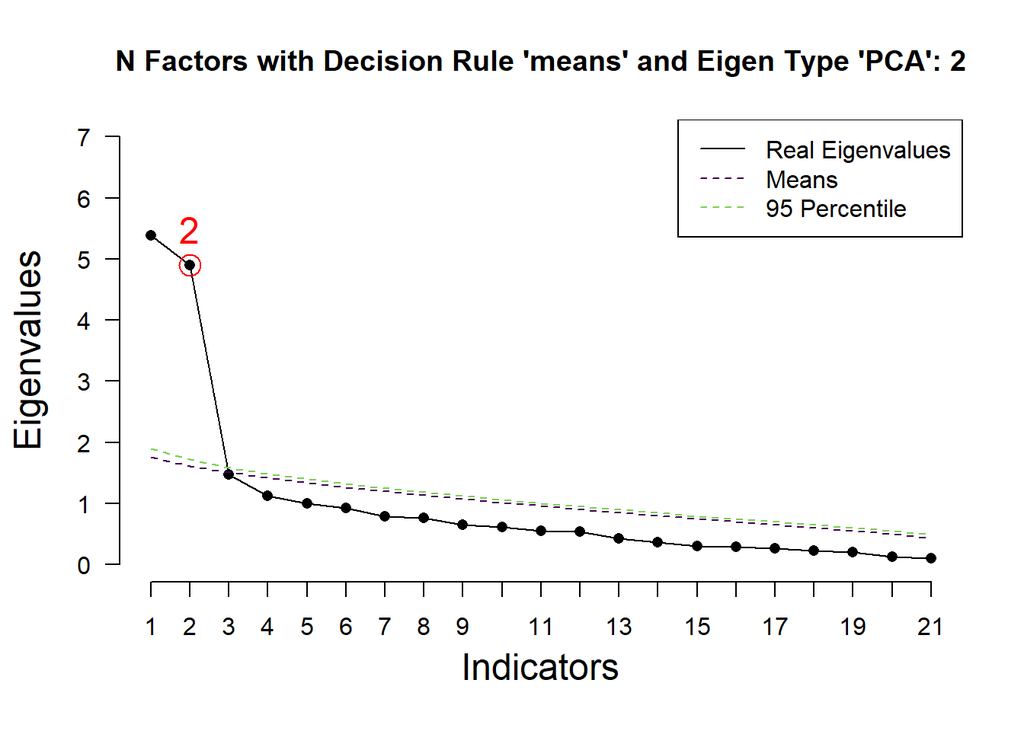

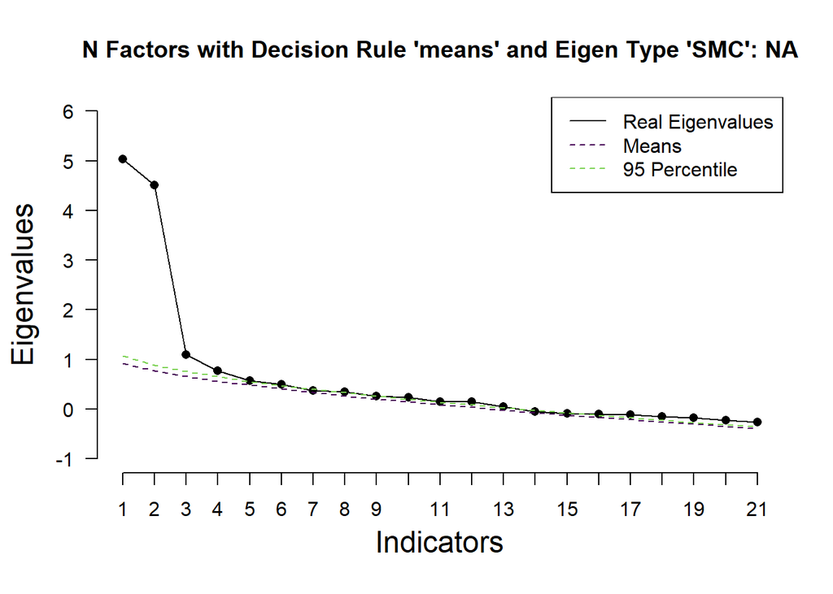

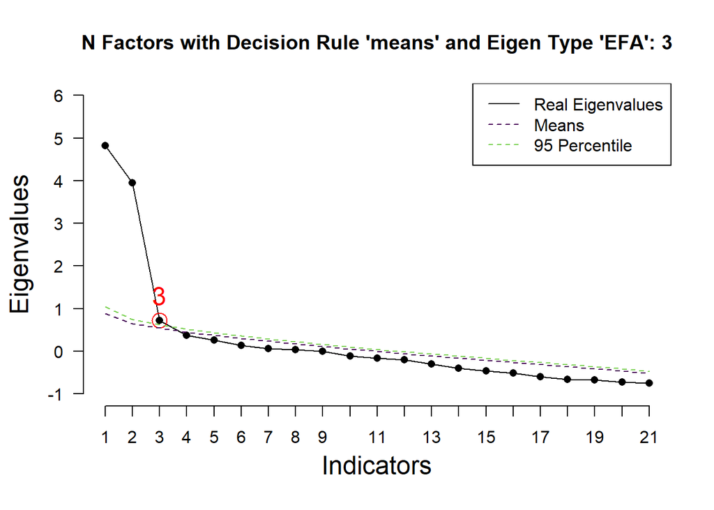

### **Paso 1.3: Ejecutar el AFE Principal (2 Factores)**

Con la justificación teórica y empírica, procedemos a ejecutar el AFE principal forzando una solución de 2 factores.

- `nfactors = 2`: Le ordenamos al modelo que busque dos factores.
- `cor = "poly"`: Usamos correlaciones policóricas, el método correcto para escalas tipo Likert (ordinales).
- `fm = "pa"`: Usamos “Principal Axis Factoring”, un método de extracción robusto que no asume normalidad.
- `rotate = "oblimin"`: Usamos una rotación oblicua, que permite que los dos factores estén correlacionados.

```r
# Ejecutamos el modelo.
# Es importante mostrar las advertencias (warnings) aquí,
# ya que nos recuerdan la inestabilidad de la matriz al analizar todos los ítems juntos.
modEfa <- psych::fa(
  r = dbEfa,
  nfactors = 2,
  cor = "poly",
  fm = "pa",
  rotate = "oblimin"
)
# Imprimimos los resultados.
# cut = 0.4 -> Oculta cargas factoriales bajas para una mejor lectura.
# sort = TRUE -> Ordena los ítems por su carga factorial.
print(modEfa, cut = 0.4, sort = TRUE)
```

```
## Factor Analysis using method =  pa
## Call: psych::fa(r = dbEfa, nfactors = 2, rotate = "oblimin", fm = "pa",
##     cor = "poly")
## Standardized loadings (pattern matrix) based upon correlation matrix
##             item   PA1   PA2   h2   u2 com
## q11_td_bio     9  0.86       0.79 0.21 1.1
## q14_rep_bio   12  0.82       0.75 0.25 1.1
## q21_bf_bio    16  0.77       0.62 0.38 1.2
## q6_bf_bio      4  0.74       0.54 0.46 1.0
## q13_al_bio    11  0.74       0.55 0.45 1.0
## q12_bf_bio    10  0.73       0.59 0.41 1.1
## q4_td_bio      2  0.72       0.61 0.39 1.5
## q19_td_bio    14  0.71       0.51 0.49 1.0
## q10_bf_bio     8  0.66       0.45 0.55 1.1
## q9_td_bio      7  0.66       0.45 0.55 1.1
## q5_al_bio      3  0.60       0.41 0.59 1.3
## q18_rep_ant   13        0.80 0.64 0.36 1.0
## q22_bf_ant    17        0.78 0.63 0.37 1.0
## q20_bf_ant    15        0.73 0.54 0.46 1.1
## q26_td_ant    20        0.67 0.45 0.55 1.0
## q7_al_ant      5        0.66 0.45 0.55 1.1
## q27_bf_ant    21        0.64 0.40 0.60 1.0
## q8_rep_ant     6        0.63 0.44 0.56 1.1
## q23_td_ant    18        0.63 0.47 0.53 1.3
## q24_td_ant    19        0.62 0.40 0.60 1.0
## q2_bf_ant      1        0.55 0.32 0.68 1.1
##
##                        PA1  PA2
## SS loadings           6.05 4.96
## Proportion Var        0.29 0.24
## Cumulative Var        0.29 0.52
## Proportion Explained  0.55 0.45
## Cumulative Proportion 0.55 1.00
##
##  With factor correlations of
##       PA1   PA2
## PA1  1.00 -0.07
## PA2 -0.07  1.00
##
## Mean item complexity =  1.1
## Test of the hypothesis that 2 factors are sufficient.
##
## df null model =  210  with the objective function =  41.77 with Chi Square =  5604.06
## df of  the model are 169  and the objective function was  30.72
##
## The root mean square of the residuals (RMSR) is  0.09
## The df corrected root mean square of the residuals is  0.1
##
## The harmonic n.obs is  143 with the empirical chi square  441.51  with prob <  3.1e-26
## The total n.obs was  143  with Likelihood Chi Square =  4080.01  with prob <  0
##
## Tucker Lewis Index of factoring reliability =  0.09
## RMSEA index =  0.402  and the 90 % confidence intervals are  0.393 0.414
## BIC =  3241.29
## Fit based upon off diagonal values = 0.95
## Measures of factor score adequacy
##                                                    PA1  PA2
## Correlation of (regression) scores with factors   0.99 0.96
## Multiple R square of scores with factors          0.98 0.92
## Minimum correlation of possible factor scores     0.96 0.84
```

## **Parte 2: Análisis Jerárquico de las Subescalas**

Una vez validada la estructura de dos grandes factores, “hacemos zoom” en cada uno para confirmar su unidimensionalidad.

### **Paso 2.1: Separar las Subescalas**

Creamos dos nuevos dataframes, uno para cada constructo, usando los ítems finales depurados.

```r
# Seleccionamos las columnas que contienen "bio" para la escala Biocéntrica
bio <- dbEfa %>%
  select(contains("bio"))

# Seleccionamos las columnas que contienen "ant" para la escala Antropocéntrica
ant <- dbEfa %>%
    select(contains("ant"))
```

### **Paso 2.2: Decidir Factores para Cada Subescala**

Repetimos el Análisis Paralelo, esta vez por separado para cada subescala. Esto nos dirá si cada una de ellas es, en efecto, unidimensional.

```r
# Análisis Paralelo para la subescala Biocéntrica
EFAtools::PARALLEL(bio)
```

```
## ℹ 'x' was not a correlation matrix. Correlations are found from entered raw data.
```

```
## Parallel Analysis performed using 1000 simulated random data sets
## Eigenvalues were found using PCA, SMC, and EFA
##
## Decision rule used: means
##
## ── Number of factors to retain according to ────────────────────────────────────
##
## ◌ PCA-determined eigenvalues:  1
## ◌ SMC-determined eigenvalues:  5
## ◌ EFA-determined eigenvalues:  4
```

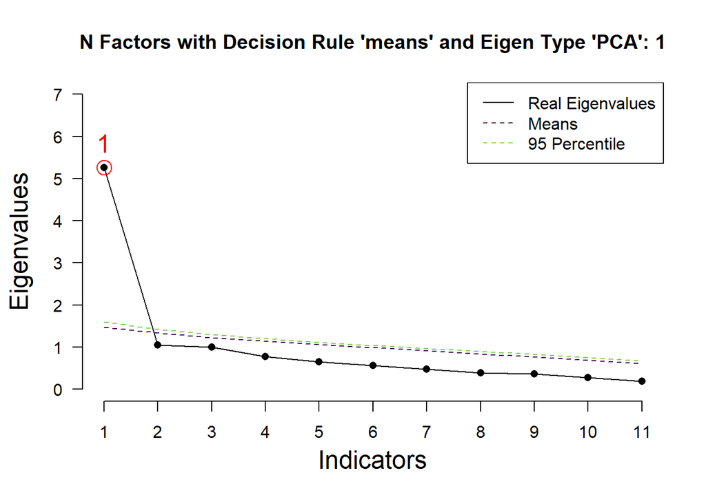

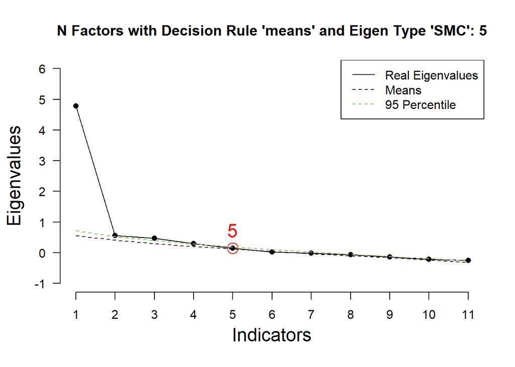

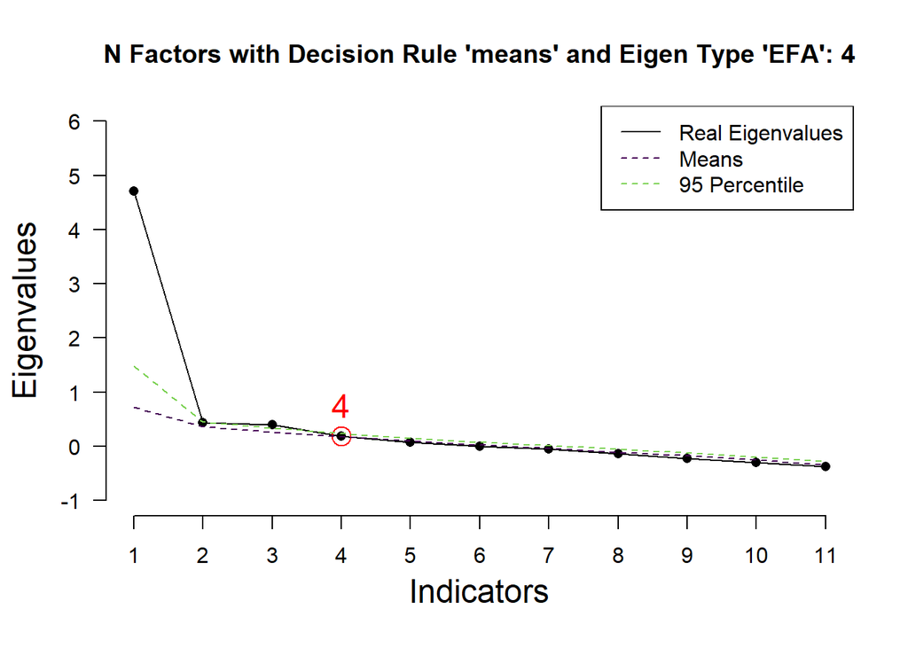

```r
# Análisis Paralelo para la subescala Antropocéntrica
EFAtools::PARALLEL(ant)
```

```
## ℹ 'x' was not a correlation matrix. Correlations are found from entered raw data.
```

```
## Parallel Analysis performed using 1000 simulated random data sets
## Eigenvalues were found using PCA, SMC, and EFA
##
## Decision rule used: means
##
## ── Number of factors to retain according to ────────────────────────────────────
##
## ◌ PCA-determined eigenvalues:  1
## ◌ SMC-determined eigenvalues:  5
## ◌ EFA-determined eigenvalues:  2
```

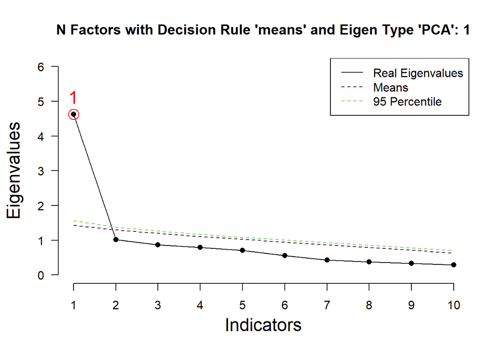

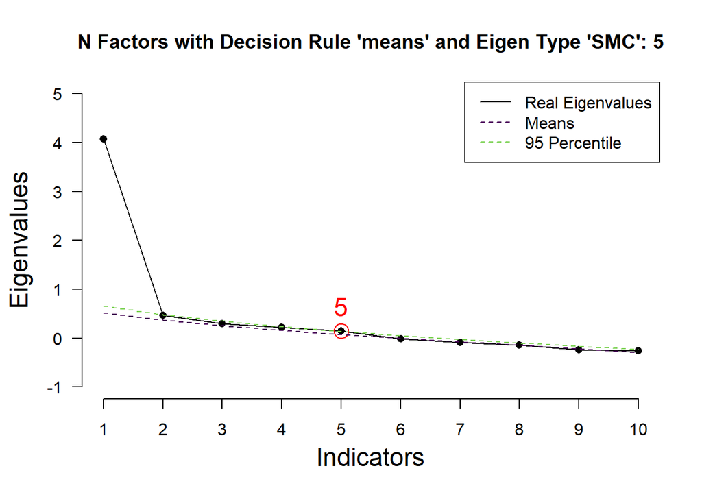

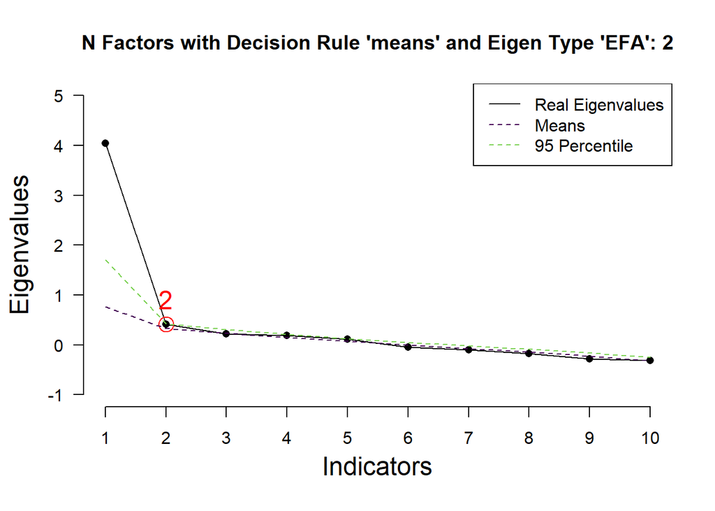

*Nota: En ambos casos, el método más fiable (PCA-determined) sugiere **1 solo factor**, lo que nos da luz verde para probar la unidimensionalidad.*

### **Paso 2.3: Ejecutar los AFE Finales (1 Factor)**

Finalmente, corremos un AFE para cada subescala forzando una solución de 1 factor. Esto nos permite ver las cargas factoriales de cada ítem en su constructo y evaluar la coherencia interna de cada escala final.

```r
# AFE para la subescala Biocéntrica (confirmando 1 factor)
modelo_bio_final <- fa(
  r = bio,
  nfactors = 1,
  cor = "poly",
  fm = "pa"
)
print(modelo_bio_final)
```

```
## Factor Analysis using method =  pa
## Call: fa(r = bio, nfactors = 1, fm = "pa", cor = "poly")
## Standardized loadings (pattern matrix) based upon correlation matrix
##              PA1   h2   u2 com
## q4_td_bio   0.68 0.47 0.53   1
## q5_al_bio   0.58 0.33 0.67   1
## q6_bf_bio   0.75 0.56 0.44   1
## q9_td_bio   0.67 0.44 0.56   1
## q10_bf_bio  0.65 0.42 0.58   1
## q11_td_bio  0.87 0.76 0.24   1
## q12_bf_bio  0.73 0.54 0.46   1
## q13_al_bio  0.74 0.55 0.45   1
## q14_rep_bio 0.83 0.68 0.32   1
## q19_td_bio  0.72 0.52 0.48   1
## q21_bf_bio  0.74 0.55 0.45   1
##
##                 PA1
## SS loadings    5.83
## Proportion Var 0.53
##
## Mean item complexity =  1
## Test of the hypothesis that 1 factor is sufficient.
##
## df null model =  55  with the objective function =  8.01 with Chi Square =  1101.07
## df of  the model are 44  and the objective function was  2.05
##
## The root mean square of the residuals (RMSR) is  0.08
## The df corrected root mean square of the residuals is  0.09
##
## The harmonic n.obs is  143 with the empirical chi square  98.45  with prob <  4.8e-06
## The total n.obs was  143  with Likelihood Chi Square =  280.15  with prob <  4e-36
##
## Tucker Lewis Index of factoring reliability =  0.716
## RMSEA index =  0.194  and the 90 % confidence intervals are  0.173 0.216
## BIC =  61.79
## Fit based upon off diagonal values = 0.98
## Measures of factor score adequacy
##                                                    PA1
## Correlation of (regression) scores with factors   0.97
## Multiple R square of scores with factors          0.94
## Minimum correlation of possible factor scores     0.87
```

```r
# AFE para la subescala Antropocéntrica (confirmando 1 factor)
modelo_ant_final <- fa(
  r = ant,
  nfactors = 1,
  cor = "poly",
  fm = "pa"
)
print(modelo_ant_final)
```

```
## Factor Analysis using method =  pa
## Call: fa(r = ant, nfactors = 1, fm = "pa", cor = "poly")
## Standardized loadings (pattern matrix) based upon correlation matrix
##              PA1   h2   u2 com
## q2_bf_ant   0.57 0.32 0.68   1
## q7_al_ant   0.68 0.46 0.54   1
## q8_rep_ant  0.66 0.43 0.57   1
## q18_rep_ant 0.80 0.64 0.36   1
## q20_bf_ant  0.70 0.49 0.51   1
## q22_bf_ant  0.78 0.61 0.39   1
## q23_td_ant  0.66 0.43 0.57   1
## q24_td_ant  0.64 0.41 0.59   1
## q26_td_ant  0.63 0.40 0.60   1
## q27_bf_ant  0.61 0.38 0.62   1
##
##                 PA1
## SS loadings    4.58
## Proportion Var 0.46
##
## Mean item complexity =  1
## Test of the hypothesis that 1 factor is sufficient.
##
## df null model =  45  with the objective function =  5.26 with Chi Square =  725.09
## df of  the model are 35  and the objective function was  1.27
##
## The root mean square of the residuals (RMSR) is  0.09
## The df corrected root mean square of the residuals is  0.1
##
## The harmonic n.obs is  143 with the empirical chi square  97.16  with prob <  9.3e-08
## The total n.obs was  143  with Likelihood Chi Square =  174.8  with prob <  1.7e-20
##
## Tucker Lewis Index of factoring reliability =  0.734
## RMSEA index =  0.167  and the 90 % confidence intervals are  0.143 0.193
## BIC =  1.1
## Fit based upon off diagonal values = 0.97
## Measures of factor score adequacy
##                                                    PA1
## Correlation of (regression) scores with factors   0.95
## Multiple R square of scores with factors          0.90
## Minimum correlation of possible factor scores     0.81
```

## **Parte 3: Resultados para Publicación Académica**

### **3.1 Resultados**

#### **Estructura Factorial del Instrumento**

El modelo de dos factores explicó el 52% de la varianza total (Factor 1: 29%, Factor 2: 24%), con cargas factoriales superiores a 0.40 en todos los ítems retenidos. La correlación entre factores fue baja (r = -0.07), indicando que las dimensiones biocéntrica y antropocéntrica representan constructos relativamente independientes, consistente con la literatura previa que sugiere que estas perspectivas no son necesariamente opuestas sino complementarias.

#### **Dimensión Biocéntrica**

Los ítems con mayor peso factorial incluyeron conceptos relacionados con el valor intrínseco de la naturaleza (q11_td_bio: λ = 0.86), el respeto por todas las formas de vida (q14_rep_bio: λ = 0.82), y la consideración de la naturaleza como un fin en sí mismo (q21_bf_bio: λ = 0.77). Estos resultados son consistentes con la conceptualización teórica del biocentrismo como una perspectiva que reconoce el valor inherente de todos los seres vivos.

#### **Dimensión Antropocéntrica**

Los ítems con mayor saturación factorial reflejaron la conceptualización de la naturaleza como recurso para el bienestar humano (q18_rep_ant: λ = 0.80), la priorización de necesidades humanas sobre consideraciones ambientales (q22_bf_ant: λ = 0.78), y la valoración instrumental de los recursos naturales (q20_bf_ant: λ = 0.73).

#### **Depuración del Instrumento**

Se eliminaron 7 ítems durante el proceso de depuración debido a: (a) cargas factoriales cruzadas superiores a 0.30, (b) cargas factoriales principales inferiores a 0.40, o (c) contribución a la inestabilidad de la matriz de correlaciones. Los ítems eliminados fueron: q1_bf_ant, q3_al_ant, q15_al_ant, q17_td_ant, q25_al_bio, q28_rep_bio, y q16_bf_bio.

### **3.2 Discusión**

La independencia relativa entre ambas dimensiones (r = -0.07) sugiere que los individuos pueden sostener simultáneamente elementos de ambas perspectivas, lo cual es consistente con investigaciones previas que han encontrado que las actitudes ambientales son multifacéticas y no necesariamente mutuamente excluyentes (Milfont & Duckitt, 2010).

### **3.3 Limitaciones y Direcciones Futuras**

Se recomienda la validación cruzada del instrumento en poblaciones diversas y la evaluación de su invariancia factorial across diferentes grupos demográficos. Adicionalmente, estudios futuros deberían explorar la validez predictiva de ambas dimensiones en relación con comportamientos proambientales específicos.

### **3.4 Análisis Factorial Confirmatorio**

Una vez establecida la estructura factorial mediante AFE, el siguiente paso lógico sería confirmar esta estructura mediante Análisis Factorial Confirmatorio (AFC). El modelo propuesto incluiría:

```r
# Modelo teórico para AFC
# Factor 1: Perspectiva Biocéntrica
# - q4_td_bio, q5_al_bio, q6_bf_bio, q9_td_bio, q10_bf_bio
# - q11_td_bio, q12_bf_bio, q13_al_bio, q14_rep_bio, q19_td_bio, q21_bf_bio

# Factor 2: Perspectiva Antropocéntrica
# - q2_bf_ant, q7_al_ant, q8_rep_ant, q18_rep_ant, q20_bf_ant
# - q22_bf_ant, q23_td_ant, q24_td_ant, q26_td_ant, q27_bf_ant

# El modelo AFC evaluaría:
# 1. Ajuste global del modelo (χ², CFI, TLI, RMSEA, SRMR)
# 2. Cargas factoriales estandarizadas
# 3. Correlación entre factores
# 4. Invariancia factorial across grupos
```

#### **Criterios de Ajuste Esperados**

Para considerar el modelo como aceptable, se esperarían los siguientes indicadores de ajuste:

- **χ²/gl < 3.0**: Indicador de ajuste global
- **CFI > 0.95**: Índice de ajuste comparativo
- **TLI > 0.95**: Índice de Tucker-Lewis
- **RMSEA < 0.08**: Error cuadrático medio de aproximación
- **SRMR < 0.08**: Residuo estandarizado

#### **Invariancia Factorial**

El análisis de invariancia evaluaría si la estructura factorial se mantiene constante across diferentes grupos (género, edad, nivel educativo), lo cual es crucial para garantizar que el instrumento mide los mismos constructos en diferentes poblaciones.

### **3.5 Conclusiones**

El instrumento depurado de 21 ítems (11 biocéntricos, 10 antropocéntricos) representa una herramienta prometedora para la evaluación de orientaciones ambientales en investigación psicológica y aplicada. Los resultados apoyan la utilidad teórica y práctica de distinguir entre perspectivas biocéntricas y antropocéntricas como dimensiones complementarias en lugar de opuestas.

La confirmación de esta estructura mediante AFC y la evaluación de validez predictiva constituyen pasos esenciales para el establecimiento definitivo de las propiedades psicométricas del instrumento.

## **Referencias**

Milfont, T. L., & Duckitt, J. (2010). The environmental attitudes inventory: A valid and reliable measure to assess the structure of environmental attitudes. *Journal of Environmental Psychology*, 30(1), 80-94.

Stern, P. C., & Dietz, T. (1994). The value basis of environmental concern. *Journal of Social Issues*, 50(3), 65-84.

Thompson, S. C. G., & Barton, M. A. (1994). Ecocentric and anthropocentric attitudes toward the environment. *Journal of Environmental Psychology*, 14(2), 149-157.